# Reproducible code for modeling results

Eric Schulz

May 15, 2018

### Load packages and take a first look at the data

Let’s first load the necessary packages, plyr for data handling, lsr to calclulate Cohen’s d, and BayesFactor for the BF for a t-test.

```r
packages <- c('plyr', 'lsr', 'BayesFactor')
lapply(packages, require, character.only = TRUE)
```

Let’s also load the data and have a look at it.

```r
#Experimental data
dat<-read.csv("kwgdata.csv")
#show first 5 entries
head(dat, 5)
```

```
##   X id  cond age x y  z trial round agegroup
## 1 1  1 Rough   7 1 6 24     0     1      7-8
## 2 2  1 Rough   7 0 4 20     1     1      7-8
## 3 3  1 Rough   7 2 4 23     2     1      7-8
## 4 4  1 Rough   7 3 4  2     3     1      7-8
## 5 5  1 Rough   7 2 5 18     4     1      7-8
```

```r
#GP-UCB results
drbf<-read.csv("rbf.csv")
#show first 5 entries
head(drbf, 5)
```

```
##   X.3  X X.1      X.2      par1      par2      par3 id
## 1   1 cv   1 99.84684 0.2040703 -4.999912 -1.949213  1
## 2   2 cv   2 91.41797 0.1898520 -4.999835 -1.977798  1
## 3   3 cv   3 92.56595 0.2277137 -4.999999 -1.939708  1
## 4   4 cv   4 85.96761 0.1844316 -5.000000 -1.956907  1
## 5   5 cv   5 91.25764 0.2159775 -4.999955 -1.939044  1
```

```r
#Mean Tracker results
dbmt<-read.csv("bmt.csv")
#show first 5 entries
head(dbmt, 5)
```

```
##   X.3  X X.1       X.2     par1      par2      par3 id
## 1   1 cv   1 104.65275 1.204857 -1.386092 -3.290274  1
## 2   2 cv   2  98.27110 1.171406 -1.513109 -3.034178  1
## 3   3 cv   3 103.53462 1.343722 -1.349907 -3.431112  1
## 4   4 cv   4 100.41234 1.159943 -1.546804 -3.052721  1
## 5   5 cv   5  99.03616 1.272997 -1.415598 -3.210195  1
```

### Create variables for predictive performance comparison

First, let’s calculate the r^2-values of the predictive performance. This is based on 25 trials predicting one of 64 options.

```r
#get pseudo-r2
drbf$r2<-(1-drbf$X.2/(-25*log(1/64)))
dbmt$r2<-(1-dbmt$X.2/(-25*log(1/64)))
```

Next, we create a data frame with age and condition for comparison.

```r
#get everyones agegroup and condition
dat<-ddply(dat, ~id, summarize, age=agegroup[1], cond=cond[1])
#mark model names
##RBF is the GP-UCB (has a RBF kernel)
drbf$model<-"RBF"
##BMT is the Bayesian Mean Tracker
dbmt$model<-"BMT"
#combine to new data frame
d<-data.frame(r2=c(drbf$r2, dbmt$r2), model=c(drbf$model, dbmt$model), id=c(drbf$id, dbmt$id))

#initialize
d$condition<-0
d$age<-0

#loop through d to match age and condition
for (i in 1:nrow(d)){
  d$condition[i]<-paste(dat$cond[d$id[i]==dat$id])
  d$age[i]<-paste(dat$age[d$id[i]==dat$id])
}
```

### Compare model performance

Let’s calculate the differences between the two models.

```r
#get model performance per id while keeping age and condition in the frame
dm<-ddply(d, ~model+id+age+condition, summarize, mu=mean(r2))

#test the difference overall
##t-test
t.test(subset(dm, model=="RBF")$mu-subset(dm, model=="BMT")$mu, var.equal = TRUE)
```

```
##
##  One Sample t-test
##
## data:  subset(dm, model == "RBF")$mu - subset(dm, model == "BMT")$mu
## t = 13.279, df = 159, p-value < 2.2e-16
## alternative hypothesis: true mean is not equal to 0
## 95 percent confidence interval:
##  0.1202565 0.1622765
## sample estimates:
## mean of x
## 0.1412665
```

```r
##effect-size
cohensD(subset(dm, model=="RBF")$mu-subset(dm, model=="BMT")$mu)
```

```
## [1] 1.049831
```

```r
##Bayes factor
ttestBF(subset(dm, model=="RBF")$mu-subset(dm, model=="BMT")$mu)
```

```
## Bayes factor analysis
## --------------
## [1] Alt., r=0.707 : 2.37528e+24 ±0%
##
## Against denominator:
##   Null, mu = 0
## ---
## Bayes factor type: BFoneSample, JZS
```

The GP-UCB model performed a lot better than the Bayesian mean tracker. Now let’s check what this looks like for the different age groups.

```r
#test the difference for adults
dm<-ddply(subset(d,age==">18"),  ~model+id+age+condition, summarize, mu=mean(r2))
t.test(subset(dm, model=="RBF")$mu-subset(dm, model=="BMT")$mu, var.equal = TRUE)
```

```
##
##  One Sample t-test
##
## data:  subset(dm, model == "RBF")$mu - subset(dm, model == "BMT")$mu
## t = 5.9789, df = 49, p-value = 2.522e-07
## alternative hypothesis: true mean is not equal to 0
## 95 percent confidence interval:
##  0.07134088 0.14357745
## sample estimates:
## mean of x
## 0.1074592
```

```r
cohensD(subset(dm, model=="RBF")$mu-subset(dm, model=="BMT")$mu)
```

```
## [1] 0.8455428
```

```r
ttestBF(subset(dm, model=="RBF")$mu-subset(dm, model=="BMT")$mu)
```

```
## Bayes factor analysis
## --------------
## [1] Alt., r=0.707 : 59645.6 ±0%
##
## Against denominator:
##   Null, mu = 0
## ---
## Bayes factor type: BFoneSample, JZS
```

```r
#test the difference for older children
dm<-ddply(subset(d,age=="9-11"),  ~model+id+age+condition, summarize, mu=mean(r2))
t.test(subset(dm, model=="RBF")$mu-subset(dm, model=="BMT")$mu, var.equal = TRUE)
```

```
##
##  One Sample t-test
##
## data:  subset(dm, model == "RBF")$mu - subset(dm, model == "BMT")$mu
## t = 10.923, df = 54, p-value = 2.735e-15
## alternative hypothesis: true mean is not equal to 0
## 95 percent confidence interval:
##  0.1537386 0.2228587
## sample estimates:
## mean of x
## 0.1882987
```

```r
cohensD(subset(dm, model=="RBF")$mu-subset(dm, model=="BMT")$mu)
```

```
## [1] 1.472923
```

```r
ttestBF(subset(dm, model=="RBF")$mu-subset(dm, model=="BMT")$mu)
```

```
## Bayes factor analysis
## --------------
## [1] Alt., r=0.707 : 2.473565e+12 ±0%
##
## Against denominator:
##   Null, mu = 0
## ---
## Bayes factor type: BFoneSample, JZS
```

```r
#test the difference for younger children
dm<-ddply(subset(d,age=="7-8"),  ~model+id+age+condition, summarize, mu=mean(r2))
t.test(subset(dm, model=="RBF")$mu-subset(dm, model=="BMT")$mu, var.equal = TRUE)
```

```
##
##  One Sample t-test
##
## data:  subset(dm, model == "RBF")$mu - subset(dm, model == "BMT")$mu
## t = 6.7714, df = 54, p-value = 9.685e-09
## alternative hypothesis: true mean is not equal to 0
## 95 percent confidence interval:
##  0.08796734 0.16196922
## sample estimates:
## mean of x
## 0.1249683
```

```r
cohensD(subset(dm, model=="RBF")$mu-subset(dm, model=="BMT")$mu)
```

```
## [1] 0.9130487
```

```r
ttestBF(subset(dm, model=="RBF")$mu-subset(dm, model=="BMT")$mu)
```

```
## Bayes factor analysis
## --------------
## [1] Alt., r=0.707 : 1280352 ±0%
##
## Against denominator:
##   Null, mu = 0
## ---
## Bayes factor type: BFoneSample, JZS
```

So GP-UCB performs better than the Meant Tracking Model for all age groups.

Let’s check if GP-UCB’s performance depends on participants’ age.

```r
#get only RBF for the different age groups
dm<-ddply(subset(d,model=="RBF"), ~id+age+condition, summarize, mu=mean(r2))

#difference of GP-UCB between adults and older children
t.test(subset(dm, age==">18")$mu, subset(dm, age=="9-11")$mu, var.equal = TRUE)
```

```
##
##  Two Sample t-test
##
## data:  subset(dm, age == ">18")$mu and subset(dm, age == "9-11")$mu
## t = 4.3337, df = 103, p-value = 3.418e-05
## alternative hypothesis: true difference in means is not equal to 0
## 95 percent confidence interval:
##  0.06945084 0.18665300
## sample estimates:
## mean of x mean of y
## 0.3909368 0.2628849
```

```r
cohensD(subset(dm, age==">18")$mu, subset(dm, age=="9-11")$mu)
```

```
## [1] 0.8468166
```

```r
ttestBF(subset(dm, age==">18")$mu, subset(dm, age=="9-11")$mu)
```

```
## Bayes factor analysis
## --------------
## [1] Alt., r=0.707 : 571.5297 ±0%
##
## Against denominator:
##   Null, mu1-mu2 = 0
## ---
## Bayes factor type: BFindepSample, JZS
```

```r
#difference of GP-UCB between younger and older children
t.test(subset(dm, age=="7-8")$mu, subset(dm, age=="9-11")$mu, var.equal = TRUE)
```

```
##
##  Two Sample t-test
##
## data:  subset(dm, age == "7-8")$mu and subset(dm, age == "9-11")$mu
## t = -3.3256, df = 108, p-value = 0.001206
## alternative hypothesis: true difference in means is not equal to 0
## 95 percent confidence interval:
##  -0.14770295 -0.03738362
## sample estimates:
## mean of x mean of y
## 0.1703416 0.2628849
```

```r
cohensD(subset(dm, age=="7-8")$mu, subset(dm, age=="9-11")$mu)
```

```
## [1] 0.6341597
```

```r
ttestBF(subset(dm, age=="7-8")$mu, subset(dm, age=="9-11")$mu)
```

```
## Bayes factor analysis
## --------------
## [1] Alt., r=0.707 : 24.80836 ±0%
##
## Against denominator:
##   Null, mu1-mu2 = 0
## ---
## Bayes factor type: BFindepSample, JZS
```

So GP-UCB performed better for adults than for older children, and better for older children than for younger children.

### Parameter comparison

To compare the different parameters, we first have to create a data set that contains all estimates.

```r
#create a data frame for parameters of GP-UCB
dp<-data.frame(estimate=exp(c(drbf$par1, drbf$par2,drbf$par3)),
               id=rep(drbf$id, 3),
               param=rep(c("lambda", "beta", "tau"), each=nrow(drbf)))

#initialize condition and age
dp$condition<-0
dp$age<-0

#get condition and age
for (i in 1:nrow(dp)){
  dp$condition[i]<-paste(dat$cond[dp$id[i]==dat$id])
  dp$age[i]<-paste(dat$age[dp$id[i]==dat$id])
}
```

Next, we need the Bayesian version of the Mann-Whitney-U test. We adapted this code from Eric Jan Wagenmakers.

```r
#Source Mann-Whitney-U-BF
source("mannwhitbf.R")
```

So let’s first check for differences in lambda.

```r
#LAMBDA:
#get the estimates
dlambda<-subset(dp, param=="lambda")
#mean per id as well as age
dage<-ddply(dlambda, ~id+age,summarize, mu=mean(estimate))
#Mann-Whitney-U of adults vs. older children
wilcox.test(subset(dage, age==">18")$mu, subset(dage, age=="9-11")$mu)
```

```
##
##  Wilcoxon rank sum test with continuity correction
##
## data:  subset(dage, age == ">18")$mu and subset(dage, age == "9-11")$mu
## W = 2001, p-value = 5.988e-05
## alternative hypothesis: true location shift is not equal to 0
```

```r
#get a subset
dd<-subset(dage, age %in% c(">18", "9-11"))
#rank correlation as effect size
cor(ifelse(dd$age==">18",1,0), dd$mu, method="kendall")
```

```
## [1] 0.3231035
```

```r
#Bayes Factor
outsim<-rankSumGibbsSampler(subset(dd, age==">18")$mu, subset(dd, age=="9-11")$mu, progBar = FALSE)
#get demsity
dense<- density(outsim$deltaSamples)
#approximate
ddense <- with(dense, approxfun(x, y, rule=1))
#Savage-Dickey-approximation
BF<-dcauchy(0, location = 0, scale = 1/sqrt(2), log = FALSE)/ddense(0)
#print
print(BF)
```

```
## [1] 418.4713
```

```r
#Mann-Whitney-U of younger vs. older children
wilcox.test(subset(dage, age=="9-11")$mu, subset(dage, age=="7-8")$mu)
```

```
##
##  Wilcoxon rank sum test with continuity correction
##
## data:  subset(dage, age == "9-11")$mu and subset(dage, age == "7-8")$mu
## W = 1829, p-value = 0.05888
## alternative hypothesis: true location shift is not equal to 0
```

```r
#subset of data frame only with kids
dd<-subset(dage, age %in% c("7-8", "9-11"))
#rank correlation of effect size
cor(ifelse(dd$age=="9-11",1,0), dd$mu, method="kendall")
```

```
## [1] 0.1486437
```

```r
#Bayes Factor
outsim<-rankSumGibbsSampler(subset(dd, age=="7-8")$mu, subset(dd, age=="9-11")$mu, progBar = FALSE)
dense<- density(outsim$deltaSamples)
ddense <- with(dense, approxfun(x, y, rule=1))
BF<-dcauchy(0, location = 0, scale = 1/sqrt(2), log = FALSE)/ddense(0)
print(BF)
```

```
## [1] 1.671645
```

So there is a clear difference between adults and older children as adults generalize more. There is no difference between older and younger children in how much they generalize.

Let’s check out directed exploration next.

```r
dbeta<-subset(dp, param=="beta")
#mean per id and age
dage<-ddply(dbeta, ~id+age,summarize, mu=mean(estimate))
#Mann-Whitney-U test for adults vs. old kids
wilcox.test(subset(dage, age==">18")$mu, subset(dage, age=="9-11")$mu)
```

```
##
##  Wilcoxon rank sum test with continuity correction
##
## data:  subset(dage, age == ">18")$mu and subset(dage, age == "9-11")$mu
## W = 629, p-value = 1.725e-06
## alternative hypothesis: true location shift is not equal to 0
```

```r
#subset of data frame
dd<-subset(dage, age %in% c(">18", "9-11"))
#rank correlation as effect size
cor(ifelse(dd$age==">18",1,0), dd$mu, method="kendall")
```

```
## [1] -0.3850403
```

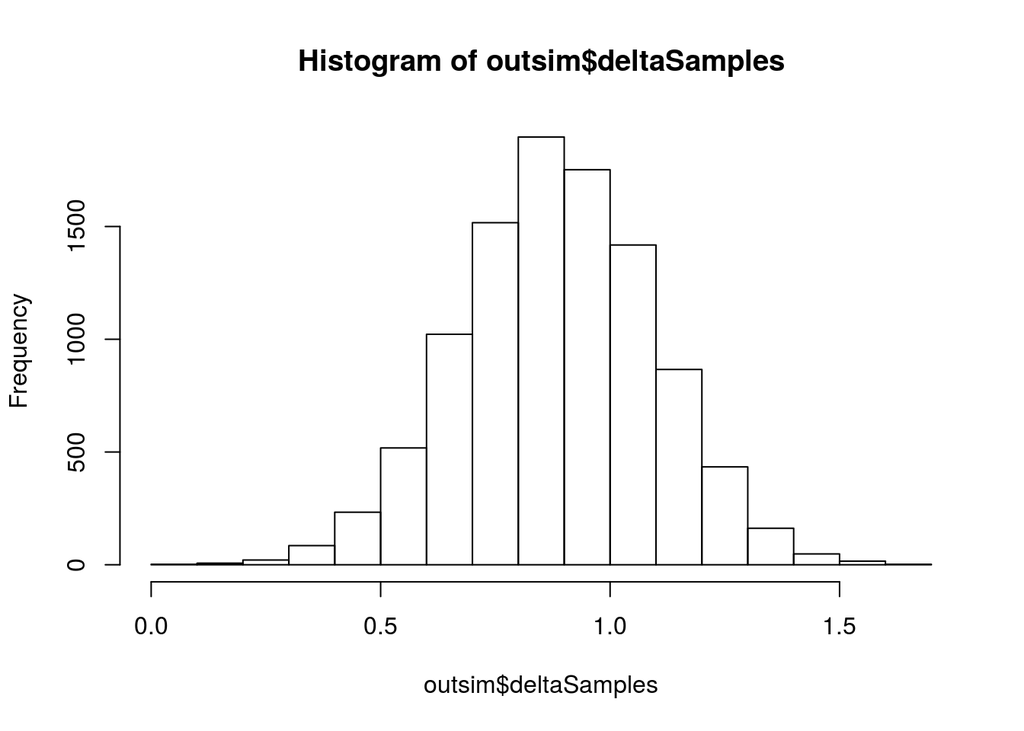

```r
#get Bayes Factor
outsim<-rankSumGibbsSampler(subset(dd, age==">18")$mu, subset(dd, age=="9-11")$mu, progBar = FALSE)
hist(outsim$deltaSamples)
```

```r
dense<- density(outsim$deltaSamples)
ddense <- with(dense, approxfun(x, y, rule=1))
#problem is that the effect is so big, it can't estimate the density at x=0
#we therefore use the even weaeker x=0.5 to approximate
#it's already much more than 100 for this already, so doesn't matter too much
BF<-dcauchy(0, location = 0, scale = 1/sqrt(2), log = FALSE)/ddense(.05)
print(BF)
```

```
## [1] 319.2418
```

```r
#Mann-Whitney-U
wilcox.test(subset(dage, age=="9-11")$mu, subset(dage, age=="7-8")$mu)
```

```
##
##  Wilcoxon rank sum test with continuity correction
##
## data:  subset(dage, age == "9-11")$mu and subset(dage, age == "7-8")$mu
## W = 1403, p-value = 0.5146
## alternative hypothesis: true location shift is not equal to 0
```

```r
#subset of children
dd<-subset(dage, age %in% c("7-8", "9-11"))
#rank correlation for effect size
cor(ifelse(dd$age=="9-11",1,0), dd$mu, method="kendall")
```

```
## [1] -0.05142648
```

```r
#Bayes Factor
outsim<-rankSumGibbsSampler(subset(dd, age=="7-8")$mu, subset(dd, age=="9-11")$mu, progBar = FALSE)
dense<- density(outsim$deltaSamples)
ddense <- with(dense, approxfun(x, y, rule=1))
BF<-dcauchy(0, location = 0, scale = 1/sqrt(2), log = FALSE)/ddense(0)
print(BF)
```

```
## [1] 0.2135288
```

Older children apply more directed exploration than adults. There is no difference between older and younger children in their directed exploration parameter.

Finally, let’s check for differences in random exploration.

```r
#tau-parameter
dtau<-subset(dp, param=="tau")
#get per age
dage<-ddply(dtau, ~id+age,summarize, mu=mean(estimate))
#do ranks
#ANOVA is impossible so, we report the biggest BF, which was for 9-11 vs adults
outsim<-rankSumGibbsSampler(subset(dage, age=="9-11")$mu, subset(dage, age==">18")$mu, progBar = FALSE)
dense<- density(outsim$deltaSamples)
ddense <- with(dense, approxfun(x, y, rule=1))
BF<-dcauchy(0, location = 0, scale = 1/sqrt(2), log = FALSE)/ddense(0)
print(BF)
```

```
## [1] 0.9409271
```

There is no difference in participants’ random exploration parameter.